# Dimintionality Reduction

| **install packages** |
| --- |

```r
if (!requireNamespace("BiocManager", quietly = TRUE))
    install.packages("BiocManager")

BiocManager::install("scater")
```

```r
BiocManager::install("SingleCellExperiment")
BiocManager::install("edgeR")
devtools::install_github("linxihui/NNLM")
install.packages("ggplot2")
```

**Load Libraries**

```r
library(scater)
library(tidyr)
library(dplyr)
library(ggplot2)
library(tidyverse)
library(Seurat)
library(RColorBrewer)
library(scales)
library(cowplot)
library(patchwork)
library(grid)
library(gridExtra)
library(harmony)
library(igraph)
library(devtools)
library("BiocManager")
library(SingleCellExperiment)
library(edgeR)
library(Rtsne)
```

```r
suppressPackageStartupMessages({
    library(SingleCellExperiment)
    library(BiocParallel)
    library(psych)
    library(GPArotation)
    library(sctransform)
    library(ica)
    library(NNLM)
  })
```

**create some functions to carry out a specific task**

**Params function**

for each dimentionality reduction method extract All requierd parameters:(example, PCA need filtering_method=“nonzeros”, norm_method=“log”), some dimensionality reduction methods (e.g.,Poisson NMF, ZINB-WaVE, pCMF, and DCA) directly model count data.

```r
params_settings <- function(method, num_clust=NULL){

    if(method=="FA"){
    #"Oblimin",included The factor correlation matrix shows the strength and direction of relationships between the factors, or factors are not allowed to correlate.
      params <- list(rotate = "oblimin", filtering_method="nonzeros", norm_method="log")
    }else if(method=="PCA"){
      params <- list(filtering_method="nonzeros", norm_method="log")
    }else if(method=="PoissonNMF"){
      params <- list(num_core=5, doParallel=TRUE, algorithm="lee", loss="mkl", filtering_method="nonzeros")
    }else if(method=="NMF"){
      params <- list(num_core=5, doParallel=TRUE, algorithm="lee", loss="mse", filtering_method="nonzeros", norm_method="log")
    }else if(method=="ICA"){
      params <- list(filtering_method="nonzeros", norm_method="log")
    }else if(method=="pCMF"){
      params <- list(num_core=20, doParallel=TRUE, filtering_method="nonzeros")
    }else if(method=="DiffusionMap"){
      params <- list(filtering_method="nonzeros", norm_method="log")
    }else if(method=="ZINBWaVE"){
      params <- list(num_core=20, doParallel=TRUE, X=NULL, V=NULL, filtering_method="nonzeros")
   } else if(method=="GLMPCA"){
      params <- list(filtering_method="nonzeros", fam="nb")
    }else if(method=="tSNE"){
      params <- list(filtering_method="nonzeros", norm_method="log", perplexity = 30)
    }else if(method=="Isomap"){
      params <- list(filtering_method="nonzeros", norm_method="log", num_prop=0.1)
    }else if(method=="LLE"){
      params <- list(filtering_method="nonzeros", norm_method="log", num_prop=0.1)
    }else if(method=="MSD"){
      params <- list(filtering_method="nonzeros", norm_method="log", num_prop=0.1)
    }else if(method=="LLLE"){
      params <- list(filtering_method="nonzeros", norm_method="log", num_prop=0.1)
    }else if(method=="LTSA"){
      params <- list(filtering_method="nonzeros", norm_method="log", num_prop=0.3)
    }else{
      stop("no defined method!")
    }# end fi

    return(params)
  }# end function parameter setting
```

**params_settings_log cpm transformation**

for each dimentionality reduction method extract All requierd parameters, when using log cpm for normalization(example, PCA need filtering_method=“nonzeros”, norm_method=“lcpm”)

```r
params_settings_lcpm <- function(method, num_clust=NULL){

    if(method=="FA"){
        params <- list(rotate = "oblimin", filtering_method="nonzeros", norm_method="lcpm")
    }else if(method=="PCA"){
        params <- list(filtering_method="nonzeros", norm_method="lcpm")

    }else if(method=="NMF"){
        params <- list(num_core=5, doParallel=TRUE, algorithm="lee", loss="mse", filtering_method="nonzeros", norm_method="lcpm")
    }else if(method=="ICA"){
        params <- list(filtering_method="nonzeros", norm_method="lcpm")
    }else if(method=="tSNE"){
        params <- list(filtering_method="nonzeros", norm_method="lcpm", perplexity = 30)
    }else{
        stop("no defined method!")
    }# end fi

    return(params)
}# end function parameter setting
```

| **dimintionality reduction methods** |
| --- |

**principal component analysis(PCA)**

```r
call_PCA <- function(sce, num_pc, params){
    ## other parameter in PCA method
    #num_clust <- params$num_clust
    filtering_method <- params$filtering_method
    norm_method <- params$norm_method
    ## normalized counts
    if(norm_method=="log"){
        norm_counts <- logcounts(sce)
    }else{
        norm_counts <- counts(sce)
    }#end func

    if(filtering_method=="nonzeros"){
        #rmoved genes that are expressed in less than five cells
      norm_counts <- norm_counts[which(rowSums(norm_counts>0)>5),]
      # keeping only the columns that have more than 10 non-zero values.
        norm_counts <- norm_counts[, which(colSums(norm_counts>0)>10)]
    }# end fi

    if(norm_method=="vst"){
        norm_counts <- VST(norm_counts)
    }else if(norm_method=="lcpm"){
        norm_counts <- cpm(norm_counts, log = TRUE,prior.count = 1)
    }else if(norm_method=="lsd"){
        norm_counts <- LSD(norm_counts)
    }else if(norm_method=="seurat"){
        norm_counts <- SeuratN(norm_counts)
    }else if(norm_method=="fq"){
        norm_counts <- FQnorm(norm_counts)
    }
    #
    #rm(sce)
    tryCatch({
        ct <- system.time({
        res_pca <- prcomp(norm_counts, center = TRUE, scale. = FALSE)
        res_pca <- res_pca$rotation[, seq_len(num_pc), drop = FALSE]
        })
        # count time (computation time)
        ct <- c(user.self = ct[["user.self"]], sys.self = ct[["sys.self"]],
            user.child = ct[["user.child"]], sys.child = ct[["sys.child"]],
            elapsed = ct[["elapsed"]])
        list(res = res_pca, ctimes = ct)
    },
    error = function(e) {
    list(res = structure(rep(NA, 1), ctimes = c(user.self = NA, sys.self = NA, user.child = NA, sys.child = NA,
                elapsed = NA), name_col = colnames(sce)))
    })
}# end func
```

**factor analysis(FA)**

```r
call_FA <- function(sce, num_pc, params){
  ## other parameter in FA method
  rotate <- params$rotate
  filtering_method <- params$filtering_method

  norm_method <- params$norm_method
  ## normalized counts
  if(norm_method=="log"){
    norm_counts <- logcounts(sce)
  }else{
    norm_counts <- counts(sce)
  }#end func

  if(filtering_method=="nonzeros"){
    norm_counts <- norm_counts[which(rowSums(norm_counts>0)>5),]
    norm_counts <- norm_counts[, which(colSums(norm_counts>0)>10)]
  }
  if(norm_method=="vst"){
    norm_counts <- VST(norm_counts)
  }else if(norm_method=="lcpm"){
    norm_counts <- cpm(norm_counts, log = TRUE,prior.count = 1)
  }else if(norm_method=="lsd"){
    norm_counts <- LSD(norm_counts)
  }else if(norm_method=="seurat"){
    norm_counts <- SeuratN(norm_counts)
  }else if(norm_method=="fq"){
    norm_counts <- FQnorm(norm_counts)
  }
  tryCatch({
    ct <- system.time({
      res_fa <- fa(r = cor(norm_counts), nfactors = num_pc, rotate = rotate)
    })
    # count time
    ct <- c(user.self = ct[["user.self"]], sys.self = ct[["sys.self"]],
            user.child = ct[["user.child"]], sys.child = ct[["sys.child"]],
            elapsed = ct[["elapsed"]])
    list(res = res_fa, ctimes = ct)
  },
  error = function(e) {
    list(res = structure(rep(NA, 1), ctimes = c(user.self = NA, sys.self = NA, user.child = NA, sys.child = NA,
                                                elapsed = NA), name_col = colnames(sce)))
  })
}# end func
```

**t-distributed stochastic neighbor embedding(TSNE)**

```r
call_tSNE <- function(sce, params){

    filtering_method <- params$filtering_method
    norm_method <- params$norm_method
    ## normalized counts
    if(norm_method=="log"){
      norm_counts <- logcounts(sce)
    }else{
      norm_counts <- counts(sce)
    }#end func

    if(filtering_method=="nonzeros"){
      norm_counts <- norm_counts[which(rowSums(norm_counts>0)>5),]
      norm_counts <- norm_counts[, which(colSums(norm_counts>0)>10)]
    }# end fi
    if(norm_method=="vst"){
          norm_counts <- VST(norm_counts)
      }else if(norm_method=="lcpm"){
          norm_counts <- cpm(norm_counts, log = TRUE,prior.count = 1)
      }else if(norm_method=="lsd"){
        norm_counts <- LSD(norm_counts)
      }else if(norm_method=="seurat"){
          norm_counts <- SeuratN(norm_counts)
      }else if(norm_method=="fq"){
          norm_counts <- FQnorm(norm_counts)
    }
    norm_counts <- t(norm_counts)

    #tsne_result <- Rtsne(norm_counts, dims = 2, perplexity = 30)

    #return(tsne_result)
    tryCatch({
    ct <- system.time({
     tsne_result <- Rtsne(norm_counts, dims = 2, perplexity = 30)
    })
    # count time
    ct <- c(user.self = ct[["user.self"]], sys.self = ct[["sys.self"]],
            user.child = ct[["user.child"]], sys.child = ct[["sys.child"]],
            elapsed = ct[["elapsed"]])
    return( list(res = tsne_result, ctimes = ct) )
  })



  }
```

**independent component analysis(ICA)**

```r
call_ICA <- function(sce, num_pc, params){
  # other parameter in FA method
  rotate <- params$rotate
  filtering_method <- params$filtering_method
  norm_method <- params$norm_method
  ## normalized counts
  if(norm_method=="log"){
    norm_counts <- logcounts(sce)
  }else{
    norm_counts <- counts(sce)
  }#end func

  if(filtering_method=="nonzeros"){
    norm_counts <- norm_counts[which(rowSums(norm_counts>0)>5),]
    norm_counts <- norm_counts[, which(colSums(norm_counts>0)>10)]
  }
  if(norm_method=="vst"){
    norm_counts <- VST(norm_counts)
  }else if(norm_method=="lcpm"){
    norm_counts <- cpm(norm_counts, log = TRUE,prior.count = 1)
  }else if(norm_method=="lsd"){
    norm_counts <- LSD(norm_counts)
  }else if(norm_method=="seurat"){
    norm_counts <- SeuratN(norm_counts)
  }else if(norm_method=="fq"){
    norm_counts <- FQnorm(norm_counts)
  }
  #rm(sce)
  norm_counts <- t(norm_counts)
  tryCatch({
    ct <- system.time({
      #norm_counts <- selectFeatures_IQR(norm_counts, nb=1000)
      res_ica <- icafast(norm_counts, num_pc)
      #res_ica$pca_comp <- res_ica$X %*% res_ica$K
      res_ica$ica_comp <- res_ica$S
    })
    # count time
    ct <- c(user.self = ct[["user.self"]], sys.self = ct[["sys.self"]],
            user.child = ct[["user.child"]], sys.child = ct[["sys.child"]],
            elapsed = ct[["elapsed"]])
    return( list(res = res_ica, ctimes = ct) )
  },
  error = function(e) {
    list(res = structure(rep(NA, 1), ctimes = c(user.self = NA, sys.self = NA, user.child = NA, sys.child = NA,elapsed = NA), name_cell = colnames(sce)))
  })
}# end func
```

**non-negative matrix factorization(NMF)**

```r
call_NMF <- function(sce, num_pc, params){
  ## other parameter in NMF method
  filtering_method <- params$filtering_method
  num_core <- params$num_core
  norm_method <- params$norm_method
  ## normalized counts
  ## normalized counts
  if(norm_method=="log"){
    norm_counts <- logcounts(sce)
  }else{
    norm_counts <- counts(sce)
  }#end func

  if(filtering_method=="nonzeros"){
    norm_counts <- norm_counts[which(rowSums(norm_counts>0)>5),]
    #norm_counts <- norm_counts[, which(colSums(norm_counts>0)>0)]
  }
  if(norm_method=="vst"){
    norm_counts <- VST(norm_counts)
  }else if(norm_method=="lcpm"){
    norm_counts <- cpm(norm_counts, log = TRUE,prior.count = 1)
  }else if(norm_method=="lsd"){# unuseful in this case
    norm_counts <- LSD(norm_counts)
  }else if(norm_method=="seurat"){
    norm_counts <- SeuratN(norm_counts)
  }else if(norm_method=="fq"){
    norm_counts <- FQnorm(norm_counts)
  }
  ##
  norm_counts <- t(norm_counts)
  tryCatch({
    ct <- system.time({
      res_nmf <- nnmf(norm_counts, num_pc, method = "lee",loss = "mse", n.threads = num_core)
    })
    # count time
    ct <- c(user.self = ct[["user.self"]], sys.self = ct[["sys.self"]],
            user.child = ct[["user.child"]], sys.child = ct[["sys.child"]],
            elapsed = ct[["elapsed"]])
    list(res = res_nmf, ctimes = ct)
  },
  error = function(e) {
    list(res = structure(rep(NA, 1), ctimes = c(user.self = NA, sys.self = NA, user.child = NA, sys.child = NA, elapsed = NA), name_col = colnames(sce)))
  })
}# end func
```

**Poisson NMF**

```r
call_PoissonNMF <- function(sce, num_pc, params){
  ## other parameter in NMF method
  filtering_method <- params$filtering_method
  num_core <- params$num_core

  ## normalized counts
  counts <- counts(sce)

  if(filtering_method=="nonzeros"){
    counts <- counts[which(rowSums(counts>0)>5),]
    counts <- counts[, which(colSums(counts>0)>10)]
  }
  counts <- t(counts)
  tryCatch({
    ct <- system.time({
      res_nmf <- nnmf(counts, num_pc, method = "lee",loss = "mkl",n.threads = num_core)
    })
    # count time
    ct <- c(user.self = ct[["user.self"]], sys.self = ct[["sys.self"]],
            user.child = ct[["user.child"]], sys.child = ct[["sys.child"]],
            elapsed = ct[["elapsed"]])
    list(res = res_nmf, ctimes = ct)
  },
  error = function(e) {
    list(res = structure(rep(NA, 1), ctimes = c(user.self = NA, sys.self = NA, user.child = NA, sys.child = NA, elapsed = NA), name_col = colnames(sce)))
  })
}# end func
```

**Extract w**

to extract component after applying reduction method(xapmle; when uing PCA w= pca component ;pca1,pca2,…etc)

```r
ExtractW <- function(res, method){
  if(method %in% c("PCA", "MDS","DiffusionMap","tSNE")){
    W = res$res
  }else if (method == "FA"){
    W = res$res$loadings[, 1:ncol(res$res$loadings)]
  }else if(method %in% c("ZIFA","scScope","DCA","umap","scvis")){
    W = res
  }else if (method %in% c("PoissonNMF", "NMF")){
    W = res$res$W
  }else if(method == "pCMF"){
    W = res$res$factor$U
  }else if(method == "ZINBWaVE"){
    W = reducedDim(res$res)
  }else if (method == "ICA"){
    W = res$res$ica_comp
  }else if (method %in% c("GLMPCA")){
    W = res$res$factors
  }else if (method %in% c("Isomap", "LLE", "LTSA")){
    W = res$res$Y
  }
  # end
  return(W)
}
```

**clustring using the k-means and hierarchical clustering algorithm**

```r
ClusteringCells <- function(W, num_clust, method='all'){
  set.seed(0)
  res <- list()
  if(method=="kmeans"){
    res[[1]] <- kmeans(W, num_clust, nstart=1000, iter.max=100000)$cluster
    names(res) <- "kmeans"
    return(res)
  }else if(method=="gmm"){#Gaussian mixture model, GMM
    library(mclust)
    res[[1]] <- MUDAN::getComMembership(W, k=num_clust, method=igraph::cluster_infomap,verbose=FALSE)
    names(res) <- "commdetec"
    return(res)
  }else if(method=="hclust"){
    library(dynamicTreeCut)
    W <- scale(W)
    d <- as.dist(1-cor(t(W)))
    hc <- hclust(d, method='ward.D')
    res[[1]] <- cutree(hc, num_clust)
    names(res) <- "hclust"
    return(res)
  }else if(method=="all"){
    res[[1]] = kmeans(W, num_clust, nstart=1000, iter.max=100000)$cluster
    library(dynamicTreeCut)
    W <- scale(W)
    d <- as.dist(1-cor(t(W)))
    hc <- hclust(d, method='ward.D')
    res[[2]] <- cutree(hc, num_clust)

    names(res) <- c("kmeans","hclust")
    return(res)
  }# end fi
}# end function
```

## **SingleCellExperiment Data**

The SingleCellExperiment class is a container for storing and manipulating single-cell genomics data.It is a part of the Bioconductor project in R, specifically designed for the analysis and representation of single-cell RNA-seq data. This class implements a data structure that stores all aspects of our single-cell data - gene-by-cell expression data, per-cell metadata and per-gene annotation and manipulate them in a synchronized manner.

```r
knitr::include_graphics("C:/Users/Lina/Desktop/scda/SingleCellExperiment.png")
```

[output not shown]

```r
NA
```

| **loading data** |
| --- |

ScRNA-seq data generated from UMI-based technologies(Baron,Zhengmix4eq) and non-UMI-based techniques(Darmanis)

Zhengmix4eq: The data set consists of four pre-sorted cell types (B-cells, naive cytotoxic T-cells, CD14 monocytes, regulatory T-cells) that were combined with equal proportions, with 1,000 cells per cell type [2]. The data were sequenced by 10x Genomics Darmanis:single cell RNA sequencing on 466 cells to capture the cellular complexity of the adult and fetal human brain, This data set originally contains 10 distinct cell groups. Clusters 1-8 consist of adult brain cells, whereas cluster 9 and 10 consist of fetal brain cells.

```r
#This data set characterized pancreatic cells from human donors
Baron <- readRDS(paste0('C:/Users/Lina/Documents/project/sce_Baron.rds') )
Zhengmix4eq <- readRDS(paste0('C:/Users/Lina/Documents/project/sce_full_Zhengmix4eq.rds') )
Darmanis <- readRDS(paste0('C:/Users/Lina/Documents/project/sce_full_Darmanis.rds') )
```

```r
Baron
```

```
class: SingleCellExperiment
dim: 14878 1886
metadata(1): log.exprs.offset
assays(2): counts logcounts
rownames(14878): X0610007P14Rik X0610009B22Rik ... Zzz3 l7Rn6
rowData names(10): feature_symbol is_feature_control ... total_counts
  log10_total_counts
colnames(1886): mouse1_lib1.final_cell_0001 mouse1_lib1.final_cell_0002 ...
  mouse2_lib3.final_cell_0394 mouse2_lib3.final_cell_0395
colData names(30): mouse phenoid ... pct_counts_ERCC is_cell_control
reducedDimNames(0):
mainExpName: NULL
altExpNames(0):
```

[output not shown]

```r
head(data.frame(logcounts(Baron)),5)
```

```r
names(colData(Baron))
```

```r
# need to manually insert the matrix into the assays,create a new assay where we add 100 to all the counts:
counts_100 <- counts(Baron) + 100
assay(Baron, "counts_100") <- counts_100 # assign a new entry to assays slot
assays(Baron) # new assay has now been added.
```

```r
# Only keeping the first two assays
assays(Baron) <- assays(Baron)[1:2]
Baron
```

```r
Zhengmix4eq
```

```r
Darmanis
```

**Performance of dimensionality reduction methods for cell clustering**

The performance of different DR methods (“PCA”,“FA”,“ICA”,“tSNE”,“NMF”,“PoissonNMF”) based on k-means and hierarchical clustering is measured by average normalized mutual information (NMI; A) and average adjusted rand index (ARI; B),across(Baron,Darmanis)dataets, for comparing the true cell labels and inferred cell label.All data normalized using log2 Count transformation for the DR method needed normalization. i compared the 3 different number of low-dimensional data. the number is equal to (0.5%, 1%, 3% )of the total number of cells,For each data set with more than 300 cells.

```r
data=list(Baron,Darmanis)
nmi_Km=0
nmi_hcl=0
ari_hcl=0
ari_Km=0
Dim_Reduction=function(method,num){
  params <- params_settings(method)
  for (i in 1:length(data)){
    true_label=as.integer(as.factor(data[[i]]$phenoid))
    num_red=as.integer(length(colnames(data[[i]]))*num)
    if (method=="tSNE"){
      res_method =call_tSNE(data[[i]],params=params)
      w=res_method$res$Y
    }
    else{

      res_method <- get(paste0("call_",method))(sce=data[[i]], num_pc=num_red, params=params)
      w=ExtractW(res_method,method)
    }
    cluster=ClusteringCells(w,length(unique(true_label)))
    nmi_Km <- compare(cluster$kmeans,true_label, method = "nmi")
    nmi_Km=nmi_Km+nmi_Km
    ari_Km <- compare(cluster$kmeans,true_label, method = "adjusted.rand")
    ari_Km=ari_Km+ari_Km
    nmi_hcl <- compare(cluster$hclust,true_label, method = "nmi")
    nmi_hcl=nmi_hcl+nmi_hcl
    ari_hcl <- compare(cluster$hclust,true_label, method = "adjusted.rand")
    ari_hcl=ari_hcl+ari_hcl
    }
  res <- c(nmi_Km/i, ari_Km/i,nmi_hcl/i, ari_hcl/i)
  names(res) <- c("nmi_Km", "ari_Km","nmi_hcl", "ari_hcl")
  return(res)
}
```

```r
#main algorithm

method=c("PCA","FA","ICA","tSNE","NMF","PoissonNMF")
dimintion=c(0.005,0.01,0.03)
nmiKm_value <- data.frame(matrix(ncol = length(method), nrow = length(dimintion)))
colnames(nmiKm_value) <- method
rownames(nmiKm_value) <- dimintion
ariKm_value <- data.frame(matrix(ncol = length(method), nrow = length(dimintion)))
colnames(ariKm_value) <- method
rownames(ariKm_value) <- dimintion
nmihcl_value <- data.frame(matrix(ncol = length(method), nrow = length(dimintion)))
colnames(nmihcl_value) <- method
rownames(nmihcl_value) <- dimintion
arihcl_value <- data.frame(matrix(ncol = length(method), nrow = length(dimintion)))
colnames(arihcl_value) <- method
rownames(arihcl_value) <- dimintion


for(i in 1 :length(dimintion)){
  for (j in 1: length(method) ){
    value=Dim_Reduction(method[j],dimintion[i])
    nmiKm_value[i,j]= value[1]
    ariKm_value[i,j]=value[2]
    nmihcl_value[i,j]=value[3]
    arihcl_value[i,j]=value[4]
  }
}
datalist=list(NMIKm=nmiKm_value,ARIkm=ariKm_value,
              NMIhcl=nmihcl_value,ARIhcl=arihcl_value)
```

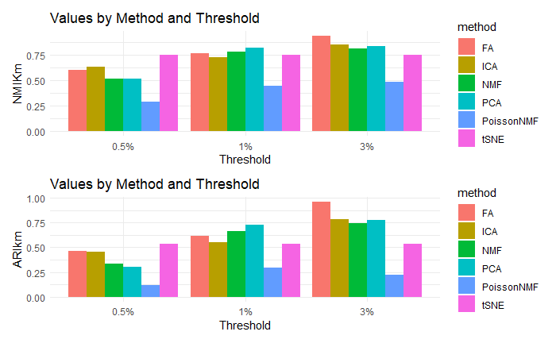

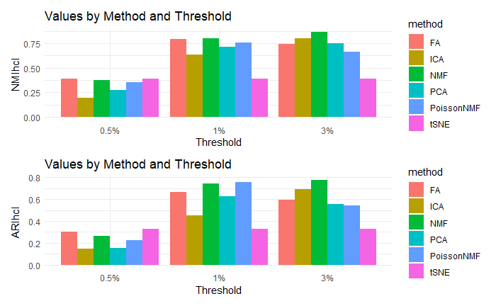

**Normalization does not influence the performance of dimensionality reduction methods**

The average performance of different DR methods (“PCA”,“FA”,“ICA”,“tSNE”,“NMF”) based on k-means clustering.The performance is measured by average normalized mutual information (NMI; A), for (Baron,Darmanis)dataets,using log2 cpm transformation.For each data set,i compared the 3 different number of low-dimensional data(0.5%, 1%, 3% on x-axis)

```r
data=list(Baron,Darmanis)
nmi_Km=0
nmi_hcl=0

Normalization_lcpm=function(method,num){
  params <- params_settings_lcpm(method)
  for (i in 1:length(data)){
    true_label=as.integer(as.factor(data[[i]]$phenoid))
    num_red=as.integer(length(colnames(data[[i]]))*num)
    if (method=="tSNE"){
      res_method =call_tSNE(data[[i]],params=params)
      w=res_method$res$Y
    }
    else{

      res_method <- get(paste0("call_",method))(sce=data[[i]], num_pc=num_red, params=params)
      w=ExtractW(res_method,method)
    }
    cluster=ClusteringCells(w,length(unique(true_label)))
    nmi_Km <- compare(cluster$kmeans,true_label, method = "nmi")
    nmi_Km=nmi_Km+nmi_Km

    nmi_hcl <- compare(cluster$hclust,true_label, method = "nmi")
    nmi_hcl=nmi_hcl+nmi_hcl

    }
  res <- c(nmi_Km/i, nmi_hcl/i)
  names(res) <- c("nmi_Km","nmi_hcl")
  return(res)
}
```

```r
#main algorithm
#execlude Poisson NMF) directly model count data
method=c("PCA","FA","ICA","tSNE","NMF")
dimintion=c(0.005,0.01,0.03)
nmiKm <- data.frame(matrix(ncol = length(method), nrow = length(dimintion)))
colnames(nmiKm) <- method
rownames(nmiKm) <- dimintion

nmihcl <- data.frame(matrix(ncol = length(method), nrow = length(dimintion)))
colnames(nmihcl) <- method
rownames(nmihcl) <- dimintion



for(i in 1 :length(dimintion)){
  for (j in 1: length(method) ){
    score=Normalization_lcpm(method[j],dimintion[i])
    nmiKm[i,j]= score[1]

    nmihcl[i,j]=score[2]

  }
}
scorelist=list(KM=nmiKm, hcl=nmihcl)
```

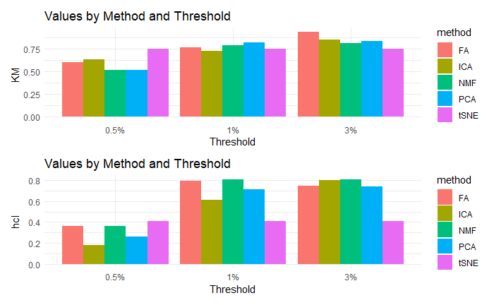

**Performance of dimensionality reduction methods in UMI vs non-UMI-based data sets**

The performance is measured by NMI for DR methods (“PCA”,“FA”,“ICA”,“tSNE”,“NMF”,“PoissonNMF”) across UMI-based data (Baron) and nonUMI-based data (Darmanis).i used log2 count transformation for the DR method reuered normalization. For each data set,i compared the 3 different number of low-dimensional data(0.5%, 1%, 3% on x-axis)of the total number of cells

```r
method=c("PCA","FA","ICA","tSNE","NMF","PoissonNMF")
dimintion=c(0.005,0.01,0.03)
nmi_value <- data.frame(matrix(ncol = length(method), nrow = length(dimintion)))
colnames(nmi_value) <- method
rownames(nmi_value) <- dimintion

UMIvsnonUMI=function(data){
  true_label=as.integer(as.factor(data$phenoid))
  for(i in 1 :length(dimintion)){
     num_red=as.integer(length(colnames(data))*dimintion[[i]])
     for (j in 1: length(method) ){
      params <- params_settings(method[j])
      if (method[j] == "tSNE"){
        res_method =call_tSNE(data,params=params)
        w=res_method$res$Y
     }else{
        res_method <- get(paste0("call_",method[j]))(sce=data, num_pc=num_red, params=params)
        w=ExtractW(res_method,method[j])
     }

      cluster=ClusteringCells(w,length(unique(data$phenoid)),method="kmeans")
      nmi_value[i,j] <- compare(cluster$kmeans,true_label, method = "nmi")

     }
  }
 return(nmi_value)

}
```

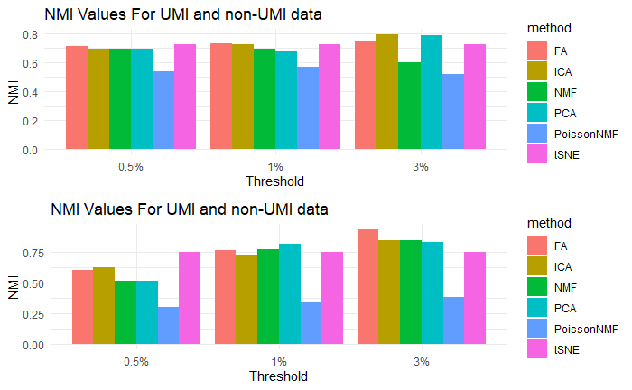

**Visualization of clustering results**

visualized the cell clustering results.using log2 count transformation for the DR method needed normalization.i applyed (“PCA”,“FA”,“ICA”,“tSNE”,“NMF”,“PoissonNMF”) DR methods to extract low-dimensional components for(Zhengmix4eq UMI-based data,low low-number=19, 4 cell types and Darmanis with high low-number=12 non-UMI-based data) have 8 cell types. Then applied tSNE method to extract the two tSNE components for visualization the clusters

```r
visulisation=function(data,num_red){
  my_plot <- list()
  method=c("PCA","FA","ICA","tSNE","NMF","PoissonNMF")
  for (i in 1: length(method) ){
     params <- params_settings(method[i])
     if (method[i] == "tSNE"){
       res_method =call_tSNE(sce=data,params=params)
       tsne_result=ExtractW(res_method,method[i])
     }else{
       res_method <- get(paste0("call_",method[i]))(sce=data, num_pc=num_red, params=params)
       w=ExtractW(res_method,method[i])
       tsne_result <- Rtsne(w, dims = 2) }
     tsne_coords <- as.data.frame(tsne_result$Y)
     tsne_coords$V1 <- tsne_result$Y[,1]  # First component on the X-axis
     tsne_coords$V2 <- tsne_result$Y[,2]  # Second component on the Y-axis
     tsne_coords$cell_type <-colData(data)$phenoid

     p=ggplot(tsne_coords, aes(x = V1, y = V2, color = cell_type)) +
       geom_point() +
       labs(title = method[i],x = "tSNE-1", y = "tSNE-2") +
       theme_minimal()
     my_plot[[i]] <- p

   }
  return(my_plot)
}
```

tSNE visualization results are not always consistent with clustering performance for different DR methods

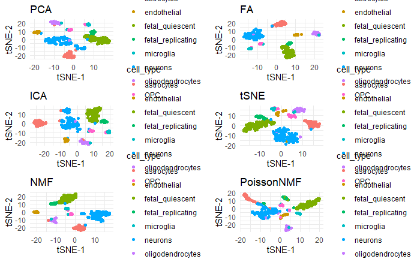

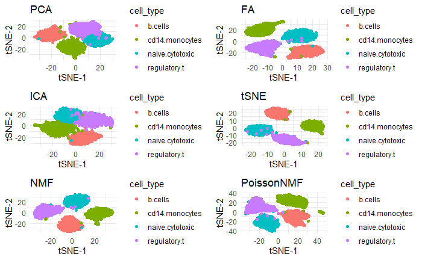

```r
# For the second dataset
grid.arrange(grobs = output[[2]], nrow = 3)
```

**Stability analysis across data splits**

```r
cell_types=colData(Baron)$phenoid
df=data.frame(cell_id = colnames(Baron), cell_type = cell_types)
df
```

| cell_id | cell_type |
| --- | --- |
| mouse1_lib1.final_cell_0001 | beta |
| mouse1_lib1.final_cell_0002 | ductal |
| mouse1_lib1.final_cell_0003 | delta |
| mouse1_lib1.final_cell_0004 | schwann |
| mouse1_lib1.final_cell_0005 | delta |
| mouse1_lib1.final_cell_0006 | beta |
| mouse1_lib1.final_cell_0007 | beta |
| mouse1_lib1.final_cell_0008 | beta |
| mouse1_lib1.final_cell_0009 | beta |
| mouse1_lib1.final_cell_0010 | ductal |

[output cut: 990 more lines]

```r
set1=list()
set2=list()
#Let's say df has 10 rows (cells). Using sample_frac(1) would randomize the rows, but all 10 rows would still be included in the output:If you wanted to shuffle but only keep 80% of the rows, you would use sample_frac(0.8).

for (i in 1:4){
 split_cells <- df %>%
   group_by(cell_type) %>%
   sample_frac(1) %>%  # Randomly shuffle the cells within each cell type

   # Assign groups 1 and 2, ensuring balance,repeats the numbers 1 and 2 to match the total number of rows in the group. This results in a new column group being added to your data frame "split_cells" that randomly assigns each cell into one of two groups.
   mutate(group = rep(1:2, length.out = n()))

   #  Create two SCE objects based on the split groups
 group_1_cells <- split_cells$cell_id[split_cells$group == 1]#extracting the cell_id values for group 1.
 group_2_cells <- split_cells$cell_id[split_cells$group == 2]#extracting the cell_id values for group 2

# Subset the original SCE object for each group,subsets Baron to include only
 sc1 <- Baron[, group_1_cells]#cells whose IDs are in group_1_cells.
 sc2 <- Baron[, group_2_cells]#cells whose IDs are in group_2_cells.
 set1=append(set1,list(sc1))
 set2=append(set2,list(sc2))


}
```

```r
split_cells
```

| cell_id | cell_type | group |
| --- | --- | --- |
| mouse2_lib3.final_cell_0274 | activated_stellate | 1 |
| mouse2_lib2.final_cell_0204 | activated_stellate | 2 |
| mouse2_lib1.final_cell_0237 | activated_stellate | 1 |
| mouse2_lib2.final_cell_0252 | activated_stellate | 2 |
| mouse2_lib3.final_cell_0016 | activated_stellate | 1 |
| mouse2_lib3.final_cell_0211 | activated_stellate | 2 |
| mouse1_lib3.final_cell_0216 | activated_stellate | 1 |
| mouse2_lib1.final_cell_0292 | activated_stellate | 2 |
| mouse2_lib1.final_cell_0285 | activated_stellate | 1 |
| mouse1_lib3.final_cell_0078 | activated_stellate | 2 |

[output cut: 990 more lines]

```r
method=c("PCA","FA","PoissonNMF")
dimintion=c(0.005,0.01,0.03)
grop_pca=data.frame(matrix(ncol = length(dimintion), nrow = length(set1)))
grop_nmf=data.frame(matrix(ncol = length(dimintion), nrow = length(set1)))
grop_fa=data.frame(matrix(ncol = length(dimintion), nrow = length(set1)))

# calculate performance for kmean clustring for each subset after apply DR method with number of low-dimensional(%0.5 and %3) from cells
accuracy_fc=function(set){
 for (i in 1:length(set)) {
    true_label=as.integer(as.factor(set[[i]]$phenoid))
    for(j in 1 :length(method)){
      params <- params_settings(method[j])
     for (z in 1: length(dimintion) ){
        num_red=as.integer(length(colnames(set[[i]]))*dimintion[[z]])
        res_method <-get(paste0("call_",method[j]))(sce=set[[i]],num_pc=num_red,params=params)
        w=ExtractW(res_method,method[j])
        cluster=ClusteringCells(w,length(unique(set[[i]]$phenoid)),method="kmeans")
        if (method[j]=="PCA"){
          grop_pca[i,z]=compare(cluster$kmeans,true_label, method = "nmi")
        }else if (method[j]=="FA"){
          grop_fa[i,z]=compare(cluster$kmeans,true_label, method = "nmi")
        }
        else if (method[j]=="PoissonNMF"){
          grop_nmf[i,z]=compare(cluster$kmeans,true_label, method = "nmi")
        }

        }



     }
  }
 result <- list(grop_pca = grop_pca, grop_fa=grop_fa, grop_nmf = grop_nmf)
 return(result)
  }
```

```r
group1=accuracy_fc(set1)
group2=accuracy_fc(set2)

#dataframe contain  accurecy result from 2 subset of Baron data after apply DR-method(PA,FA,PoissonNMF )
PCA=list(group1$grop_pca,group2$grop_pca)
PoissonNMF=list(group1$grop_nmf,group2$grop_nmf)
FA=list(group1$grop_fa,group2$grop_fa)
```

visualized the clustering performance of different dimensionality reduction methods in the two subsets separately

```r
#plot boxplot
boxplot_fc=function(group){

  df1 <- group[[1]]
  colnames(df1)=c("%0.5","%1","%3")
  df2 <- group[[2]]
  colnames(df2)=c("%0.5","%1","%3")
#change format df to new format with one column_name variable contaian all col_ames in df and col_names value contain all value fi df
  df1_long <- df1 %>%
   pivot_longer(cols = c(colnames(df1)), names_to = "Variable", values_to = "Value") %>%
   mutate(Dataset = "df1")  # Add a column for the dataset name

  df2_long <- df2 %>%
   pivot_longer(cols = everything(), names_to = "Variable", values_to = "Value") %>%
   mutate(Dataset = "df2")  # Add a column for the dataset name

# Combine both datasets for plotting col_name the same
  df_combined <- bind_rows(df1_long, df2_long)

# Create the boxplot with ggplot2
  plot_title <- deparse(substitute(group))
  ggplot(df_combined, aes(x = Variable, y = Value, fill = Dataset)) +
   geom_boxplot(position = position_dodge(width = 0.8)) +  # Position the boxes side by side
   labs(title = plot_title, x = "Variable", y = "Values") +
   scale_fill_manual(values = c("lightblue", "lightgreen")) +  # Custom colors for df1 and df2
   theme_minimal() +  # Minimal theme
   theme(axis.text.x = element_text(angle = 0, hjust = 0.5))  # Adjust x-axis labels for better readability
}
```

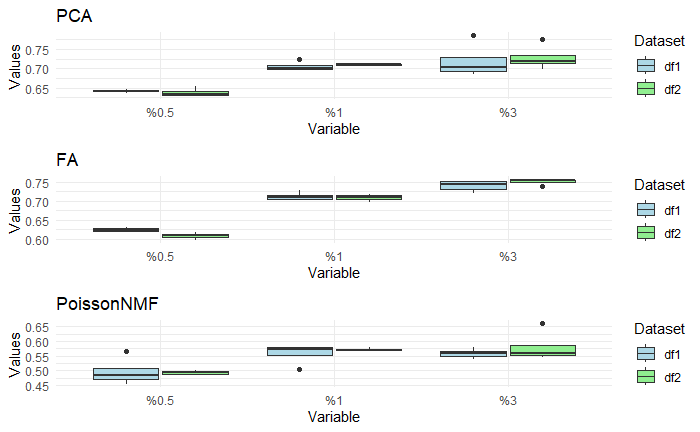

**Time Computation**

examined how computation time for different dimensionality reduction methods (“PCA”,“FA”,“ICA”,“NMF”,“tSNE”,“PoissonNMF”) varies with respect to the number of low dimensional components extracted (9,18,56), for Baron dataset.using log2 count for the DR method needed normalization

```r
method=c("PCA","FA","ICA","NMF","tSNE","PoissonNMF")
dimintion=c(9,18,56)
time_value <- data.frame(matrix(ncol = length(method), nrow = length(dimintion)))
colnames(time_value) <- method
rownames(time_value) <- dimintion

for(i in 1 :length(dimintion)){
   for (j in 1: length(method) ){
      params <- params_settings(method[j])
      if (method[j]=="tSNE"){
        RES =call_tSNE(Baron,params=params)
      }else{
        RES <- get(paste0("call_",method[j]))(sce=Baron, num_pc=dimintion[i], params=params)

        }
      time_value[i,j]=round((RES$ ctimes)["user.self"]/3600,2)

      }
   }
```

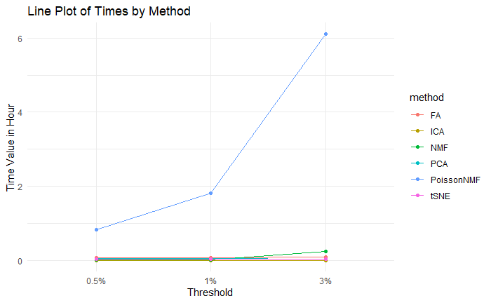

```r
time_value$threshold <-c("0.5%","1%","3%")
rownames(time_value) <- NULL

time_long <- pivot_longer(time_value,
                           cols = colnames(time_value[,-ncol(time_value)]),
                           names_to = "method",
                           values_to = "time_value")
# Plot
ggplot(time_long, aes(x = threshold, y = time_value, group = method, color = method)) +
    geom_line() +
    geom_point() + # Add points for clarity
    labs(title = "Line Plot of Times by Method",
         x = "Threshold",
         y = "Time Value in Hour") +
    theme_minimal()
```

```r
#poission nmf become noticeably computationally more expensive than the remaining methods with increasing number of low-dimensional components
```